# vehicle sillhoute (5) (2) (2) - Jupyter Notebook

#### 1.2.b:Training set of 500

```
xxxxxxxxxx
```

```
# Set a fixed random seed for reproducibility
```

```
set.seed(234)
```

```
# Randomly sample row indices for the training set
```

```
train_indices <- sample(1:nrow(dataset), 500)
```

```
# Create the training set by selecting rows based on the sampled indices
```

```
Vehicle.train <- dataset[train_indices, ]
```

```
# Create the testing set by excluding rows from the training set
```

```
Vehicle.test <- dataset[-train_indices, ]
```

```
# Extract the target variable for the testing set
```

```
class.test <- dataset$class[-train_indices]
```

```
# Fit a classification tree to your Vehicle Silhouettes dataset
```

```
library(rpart.plot)
```

```
fit.tree <- rpart(Class ~ ., data = Vehicle.train, method = "class", cp = 0.008)
```

```
# Print the fitted tree(flag)
```

```
fit.tree
```

```
xxxxxxxxxx
```

```
<PRE>n= 500
```

```
node), split, n, loss, yval, (yprob)
```

```
      * denotes terminal node
```

```
 1) root 500 332 1 (0.33600000 0.33000000 0.33400000)
```

```
   2) elongatedness< 42.5 198  75 2 (0.35353535 0.62121212 0.02525253)
```

```
     4) max.length_aspect_ratio< 7.5 76   9 1 (0.88157895 0.11842105 0.00000000) *
```

```
     5) max.length_aspect_ratio>=7.5 122   8 2 (0.02459016 0.93442623 0.04098361) *
```

```
   3) elongatedness>=42.5 302 140 3 (0.32450331 0.13907285 0.53642384)
```

```
     6) max.length_aspect_ratio< 8.5 217 122 1 (0.43778802 0.19354839 0.36866359)
```

```
      12) scaled_variance.1>=0.1492806 117  23 1 (0.80341880 0.17094017 0.02564103)
```

```
        24) max.length_rectangularity>=135.5 94   6 1 (0.93617021 0.03191489 0.03191489) *
```

```
        25) max.length_rectangularity< 135.5 23   6 2 (0.26086957 0.73913043 0.00000000)
```

```
          50) pr.axis_aspect_ratio>=61 8   2 1 (0.75000000 0.25000000 0.00000000) *
```

```
          51) pr.axis_aspect_ratio< 61 15   0 2 (0.00000000 1.00000000 0.00000000) *
```

```
      13) scaled_variance.1< 0.1492806 100  23 3 (0.01000000 0.22000000 0.77000000)
```

```
        26) max.length_rectangularity< 128.5 25  12 2 (0.00000000 0.52000000 0.48000000)
```

```
          52) scatter_ratio>=124 11   1 2 (0.00000000 0.90909091 0.09090909) *
```

```
          53) scatter_ratio< 124 14   3 3 (0.00000000 0.21428571 0.78571429) *
```

```
        27) max.length_rectangularity>=128.5 75  10 3 (0.01333333 0.12000000 0.86666667) *
```

```
    7) max.length_aspect_ratio>=8.5 85   3 3 (0.03529412 0.00000000 0.96470588) *</PRE>
```

```
n= 500

node), split, n, loss, yval, (yprob)
      * denotes terminal node

 1) root 500 332 1 (0.33600000 0.33000000 0.33400000)
   2) elongatedness< 42.5 198  75 2 (0.35353535 0.62121212 0.02525253)
     4) max.length_aspect_ratio< 7.5 76   9 1 (0.88157895 0.11842105 0.00000000) *
     5) max.length_aspect_ratio>=7.5 122   8 2 (0.02459016 0.93442623 0.04098361) *
   3) elongatedness>=42.5 302 140 3 (0.32450331 0.13907285 0.53642384)
     6) max.length_aspect_ratio< 8.5 217 122 1 (0.43778802 0.19354839 0.36866359)
      12) scaled_variance.1>=0.1492806 117  23 1 (0.80341880 0.17094017 0.02564103)
        24) max.length_rectangularity>=135.5 94   6 1 (0.93617021 0.03191489 0.03191489) *
        25) max.length_rectangularity< 135.5 23   6 2 (0.26086957 0.73913043 0.00000000)
          50) pr.axis_aspect_ratio>=61 8   2 1 (0.75000000 0.25000000 0.00000000) *
          51) pr.axis_aspect_ratio< 61 15   0 2 (0.00000000 1.00000000 0.00000000) *
      13) scaled_variance.1< 0.1492806 100  23 3 (0.01000000 0.22000000 0.77000000)
        26) max.length_rectangularity< 128.5 25  12 2 (0.00000000 0.52000000 0.48000000)
          52) scatter_ratio>=124 11   1 2 (0.00000000 0.90909091 0.09090909) *
          53) scatter_ratio< 124 14   3 3 (0.00000000 0.21428571 0.78571429) *
        27) max.length_rectangularity>=128.5 75  10 3 (0.01333333 0.12000000 0.86666667) *
    7) max.length_aspect_ratio>=8.5 85   3 3 (0.03529412 0.00000000 0.96470588) *
```

```
xxxxxxxxxx
```

```
The decision tree analysis on the dataset, reveals a hierarchical structure for classifying vehicles into three categories: cars, vans, and buses. The tree primarily uses features such as elongatedness, max.length_aspect_ratio, and scaled_variance.1 to make distinctions. Instances with low elongatedness are further classified based on max.length_aspect_ratio, showcasing clear decision boundaries. Notably, the tree identifies specific conditions, such as scaled_variance.1 and max.length_rectangularity, that significantly contribute to the classification process. The resulting tree is interpretable, providing insights into the key features influencing the categorization of vehicle silhouettes.
```

The decision tree analysis on the dataset, reveals a hierarchical structure for classifying vehicles into three categories: cars, vans, and buses. The tree primarily uses features such as elongatedness, max.length_aspect_ratio, and scaled_variance.1 to make distinctions. Instances with low elongatedness are further classified based on max.length_aspect_ratio, showcasing clear decision boundaries. Notably, the tree identifies specific conditions, such as scaled_variance.1 and max.length_rectangularity, that significantly contribute to the classification process. The resulting tree is interpretable, providing insights into the key features influencing the categorization of vehicle silhouettes.

```
xxxxxxxxxx
```

```
#Visualize the Classification Tree
```

```
install.packages("rpart.plot")
```

```
library(rpart.plot)
```

```
rpart.plot(fit.tree)
```

```
xxxxxxxxxx
```

```
![LENA2.png](attachment:LENA2.png)
```

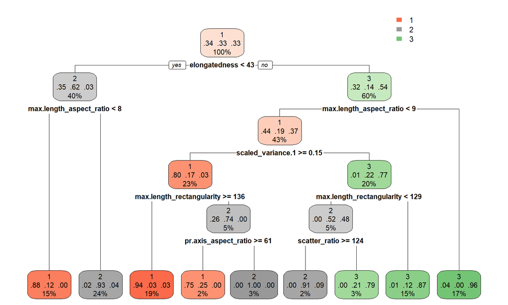

```
xxxxxxxxxx
```

```
The tree's root node indicates an overall balance in class distribution, with approximately one-third of the samples belonging to each category. The first split highlights the significance of elongatedness, with a clear separation based on this feature. Instances with elongatedness below 42.5 are further classified primarily using max.length_aspect_ratio, leading to distinct subgroups within the van and car categories.
```

```
For instances with elongatedness above 42.5, the tree relies on max.length_aspect_ratio and scaled_variance.1, emphasizing the importance of these features in distinguishing between bus and car categories. Notably, the tree identifies specific conditions, such as max.length_rectangularity and scatter_ratio, that significantly contribute to the classification process, especially for instances with elongatedness above 42.5.
```

The tree's root node indicates an overall balance in class distribution, with approximately one-third of the samples belonging to each category. The first split highlights the significance of elongatedness, with a clear separation based on this feature. Instances with elongatedness below 42.5 are further classified primarily using max.length_aspect_ratio, leading to distinct subgroups within the van and car categories.

For instances with elongatedness above 42.5, the tree relies on max.length_aspect_ratio and scaled_variance.1, emphasizing the importance of these features in distinguishing between bus and car categories. Notably, the tree identifies specific conditions, such as max.length_rectangularity and scatter_ratio, that significantly contribute to the classification process, especially for instances with elongatedness above 42.5.

```
xxxxxxxxxx
```

```
# Checking the order of variable importance
```

```
fit.tree$variable.importance
```

```
xxxxxxxxxx
```

```
<pre>scaled_variance.1               scatter_ratio               elongatedness
```

```
                 141.700274                  138.090203                  124.124443
```

```
            scaled_variance     max.length_aspect_ratio        distance_circularity
```

```
                 113.208260                  102.776838                   86.688432
```

```
                circularity                radius_ratio   scaled_radius_of_gyration
```

```
                  63.771169                   50.271410                   46.705339
```

```
  max.length_rectangularity               hollows_ratio scaled_radius_of_gyration.1
```

```
                  43.025703                   25.524834                   25.391575
```

```
           skewness_about.2        pr.axis_aspect_ratio            skewness_about.1
```

```
                  24.661293                   22.282573                    8.459387
```

```
             skewness_about
```

```
                   2.201087 </pre>
```

```
scaled_variance.1               scatter_ratio               elongatedness
                 141.700274                  138.090203                  124.124443
            scaled_variance     max.length_aspect_ratio        distance_circularity
                 113.208260                  102.776838                   86.688432
                circularity                radius_ratio   scaled_radius_of_gyration
                  63.771169                   50.271410                   46.705339
  max.length_rectangularity               hollows_ratio scaled_radius_of_gyration.1
                  43.025703                   25.524834                   25.391575
           skewness_about.2        pr.axis_aspect_ratio            skewness_about.1
                  24.661293                   22.282573                    8.459387
             skewness_about
                   2.201087
```

```
xxxxxxxxxx
```

```
 The variable "scaled_variance.1" holds the highest importance, with a value of 141.70, followed by "scatter_ratio" and "elongatedness" with values of 138.09 and 124.12, respectively. These values represent the contribution of each variable to the decision-making process of the model. Features such as "circularity," "radius_ratio," and "scaled_radius_of_gyration" also exhibit notable importance, suggesting their influence in distinguishing between car, van, and bus silhouettes.
```

The variable "scaled_variance.1" holds the highest importance, with a value of 141.70, followed by "scatter_ratio" and "elongatedness" with values of 138.09 and 124.12, respectively. These values represent the contribution of each variable to the decision-making process of the model. Features such as "circularity," "radius_ratio," and "scaled_radius_of_gyration" also exhibit notable importance, suggesting their influence in distinguishing between car, van, and bus silhouettes.

```
xxxxxxxxxx
```

```
#Predict Using the Classification Tree
```

```
pred.tree <- predict(fit.tree, Vehicle.test, type = "class")
```

```
# Evaluate the performance of the classification tree
```

```
confusion_matrix <- table(pred.tree, Vehicle.test$Class)
```

```
# Print or inspect the confusion matrix
```

```
print(confusion_matrix)
```

```
xxxxxxxxxx
```

```
<pre>pred.tree  1  2  3
```

```
        1 30  5  0
```

```
        2  0 26  1
```

```
        3  1  3 31</pre>
```

```
pred.tree  1  2  3
        1 30  5  0
        2  0 26  1
        3  1  3 31
```

```
xxxxxxxxxx
```

[output not shown]

```
xxxxxxxxxx
```

```
#plotcp(fit.tree)
```

```
printcp(fit.tree)
```

```
xxxxxxxxxx
```

```
<pre>Classification tree:
```

```
rpart(formula = Class ~ ., data = Vehicle.train, method = "class",
```

```
    cp = 0.008)
```

```
Variables actually used in tree construction:
```

```
[1] elongatedness             max.length_aspect_ratio   max.length_rectangularity
```

```
[4] pr.axis_aspect_ratio      scaled_variance.1         scatter_ratio
```

```
Root node error: 332/500 = 0.664
```

```
n= 500
```

```
        CP nsplit rel error  xerror     xstd
```

```
1 0.352410      0   1.00000 1.09940 0.029901
```

```
2 0.174699      1   0.64759 0.65964 0.033416
```

```
3 0.137048      2   0.47289 0.48193 0.031418
```

```
4 0.033133      4   0.19880 0.21687 0.023646
```

```
5 0.013554      5   0.16566 0.17771 0.021728
```

```
6 0.012048      7   0.13855 0.17470 0.021568
```

```
7 0.008000      8   0.12651 0.16867 0.021240</pre>
```

```
Classification tree:
rpart(formula = Class ~ ., data = Vehicle.train, method = "class",
    cp = 0.008)

Variables actually used in tree construction:
[1] elongatedness             max.length_aspect_ratio   max.length_rectangularity
[4] pr.axis_aspect_ratio      scaled_variance.1         scatter_ratio

Root node error: 332/500 = 0.664

n= 500

        CP nsplit rel error  xerror     xstd
1 0.352410      0   1.00000 1.09940 0.029901
2 0.174699      1   0.64759 0.65964 0.033416
3 0.137048      2   0.47289 0.48193 0.031418
4 0.033133      4   0.19880 0.21687 0.023646
5 0.013554      5   0.16566 0.17771 0.021728
6 0.012048      7   0.13855 0.17470 0.021568
7 0.008000      8   0.12651 0.16867 0.021240
```

```
xxxxxxxxxx
```

[output not shown]

```
xxxxxxxxxx
```

```
# Explicitly request the lowest cp value
```